# UK Monthly Trade Report

September 2026

Author

Oleksandr Shepotylo

Published

September 30, 2026

# Executive Summary

This report analyzes UK trade patterns for **September 2026**, comparing performance to:

- **August 2026** (Month-over-Month analysis)
- **September 2025** (Year-over-Year analysis)

The analysis covers:

1. Overall trade metrics (exports, imports, trade balance)
2. Top 10 products with largest absolute changes in value
3. Top 5 trading partners with largest absolute changes in value

# 1. Overall Trade Performance

## 1.1 Summary Metrics

UK Trade Metrics - September 2026

| Metric | Values Sep 2026 | Values Aug 2026 | Values Sep 2025 | Month-over-Month MoM Change | Month-over-Month MoM % | Year-over-Year YoY Change | Year-over-Year YoY % |
| --- | --- | --- | --- | --- | --- | --- | --- |
| Exports | $47.8B | $42.5B | $45.2B | $5.3B | 12.45% | $2.6B | 5.69% |
| Imports | $108.1B | $92.0B | $77.9B | $16.0B | 17.42% | $30.1B | 38.66% |
| Trade Balance | -$60.3B | -$49.5B | -$32.7B | -$10.7B | 21.67% | -$27.6B | 84.24% |

### Key Findings

**Month-over-Month (vs August 2026):**

- Exports changed by **12.45%**
- Imports changed by **17.42%**
- Trade balance changed by **$-10.7B**

**Year-over-Year (vs September 2025):**

- Exports changed by **5.69%**
- Imports changed by **38.66%**
- Trade balance changed by **$-27.6B**

## 1.2 Growth Visualization

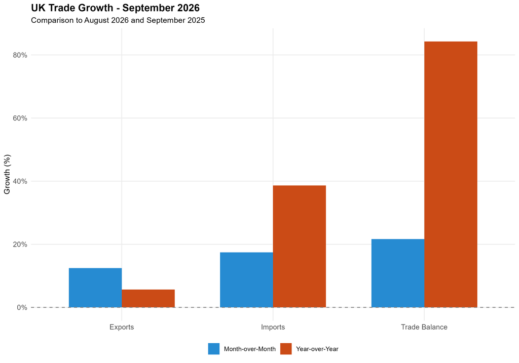

# 2. Export Analysis

## 2.1 Top Products - Month-over-Month

### Products with Largest Increases

Top 10 Export Products - Largest Increases (MoM)

| Product | Sep 2026 | Aug 2026 | Absolute Change | % Change |
| --- | --- | --- | --- | --- |
| HS 711319: Jewellery; of | $635.4M | $171.2M | $464.2M | 271.1% |
| HS 270900: Oils; petroleum | $1,454.9M | $1,023.5M | $431.4M | 42.2% |
| HS 870323: Vehicles; with | $812.3M | $414.8M | $397.5M | 95.8% |
| HS 880730: Aircraft and | $1,159.8M | $843.5M | $316.3M | 37.5% |
| HS 870324: Vehicles; with | $656.9M | $399.3M | $257.6M | 64.5% |
| HS 300490: Medicaments; consisting | $1,213.8M | $1,024.7M | $189.1M | 18.4% |
| HS 847170: Units of | $268.2M | $81.2M | $187.0M | 230.2% |
| HS 995000: NA | $1,286.0M | $1,143.2M | $142.8M | 12.5% |
| HS 271012: Petroleum oils | $725.9M | $607.9M | $117.9M | 19.4% |
| HS 847150: Units of | $319.0M | $203.6M | $115.4M | 56.7% |

### Products with Largest Decreases

Top 10 Export Products - Largest Decreases (MoM)

| Product | Sep 2026 | Aug 2026 | Absolute Change | % Change |
| --- | --- | --- | --- | --- |
| HS 271121: Petroleum gases | $800.7M | $1,368.2M | -$567.5M | -41.5% |
| HS 710813: Metals; gold, | $3,474.8M | $3,866.2M | -$391.3M | -10.1% |
| HS 300215: Blood, human | $422.0M | $584.9M | -$163.0M | -27.9% |
| HS 710691: Metals; silver, | $109.8M | $218.6M | -$108.8M | -49.8% |
| HS 854232: Electronic integrated | $57.9M | $127.7M | -$69.9M | -54.7% |
| HS 711019: Metals; platinum, | $83.6M | $129.8M | -$46.2M | -35.6% |
| HS 990938: NA | $212.5M | $246.0M | -$33.5M | -13.6% |
| HS 841182: Turbines; gas-turbines | $68.8M | $101.2M | -$32.4M | -32.0% |
| HS 711292: Waste and | $69.5M | $98.9M | -$29.3M | -29.7% |
| HS 150300: Lard stearin, | $1.3M | $29.4M | -$28.1M | -95.5% |

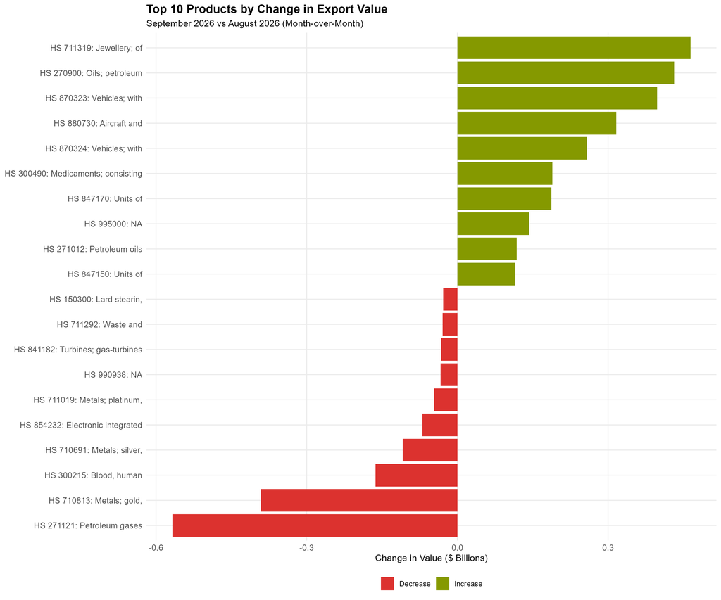

## 2.2 Top Products - Year-over-Year

### Products with Largest Increases

Top 10 Export Products - Largest Increases (YoY)

| Product | Sep 2026 | Sep 2025 | Absolute Change | % Change |
| --- | --- | --- | --- | --- |
| HS 870323: Vehicles; with | $812.3M | $147.9M | $664.4M | 449.2% |
| HS 270900: Oils; petroleum | $1,454.9M | $1,032.5M | $422.4M | 40.9% |
| HS 711319: Jewellery; of | $635.4M | $217.6M | $417.8M | 192.1% |
| HS 990285: NA | $469.9M | $164.4M | $305.5M | 185.9% |
| HS 271121: Petroleum gases | $800.7M | $531.3M | $269.4M | 50.7% |
| HS 870324: Vehicles; with | $656.9M | $390.0M | $266.9M | 68.5% |
| HS 271012: Petroleum oils | $725.9M | $459.3M | $266.6M | 58.1% |
| HS 300490: Medicaments; consisting | $1,213.8M | $949.2M | $264.6M | 27.9% |
| HS 841191: Turbines; parts | $1,853.3M | $1,610.9M | $242.4M | 15.0% |
| HS 847170: Units of | $268.2M | $71.6M | $196.6M | 274.7% |

### Products with Largest Decreases

Top 10 Export Products - Largest Decreases (YoY)

| Product | Sep 2026 | Sep 2025 | Absolute Change | % Change |
| --- | --- | --- | --- | --- |
| HS 710813: Metals; gold, | $3,474.8M | $6,523.5M | -$3,048.7M | -46.7% |
| HS 710691: Metals; silver, | $109.8M | $842.5M | -$732.7M | -87.0% |
| HS 711019: Metals; platinum, | $83.6M | $257.7M | -$174.1M | -67.6% |
| HS 870340: Vehicles; with | $194.6M | $365.7M | -$171.1M | -46.8% |
| HS 870350: Vehicles; with | $1.2M | $62.8M | -$61.5M | -98.0% |
| HS 284329: Silver compounds; | $4.2M | $65.1M | -$60.9M | -93.6% |
| HS 990897: NA | $0.0M | $59.4M | -$59.4M | -100.0% |
| HS 290121: Acyclic hydrocarbons; | $0.0M | $40.1M | -$40.1M | -100.0% |
| HS 890333: Motorboats; (other | $6.2M | $43.9M | -$37.7M | -85.8% |
| HS 870321: Vehicles; with | $30.0M | $65.8M | -$35.8M | -54.5% |

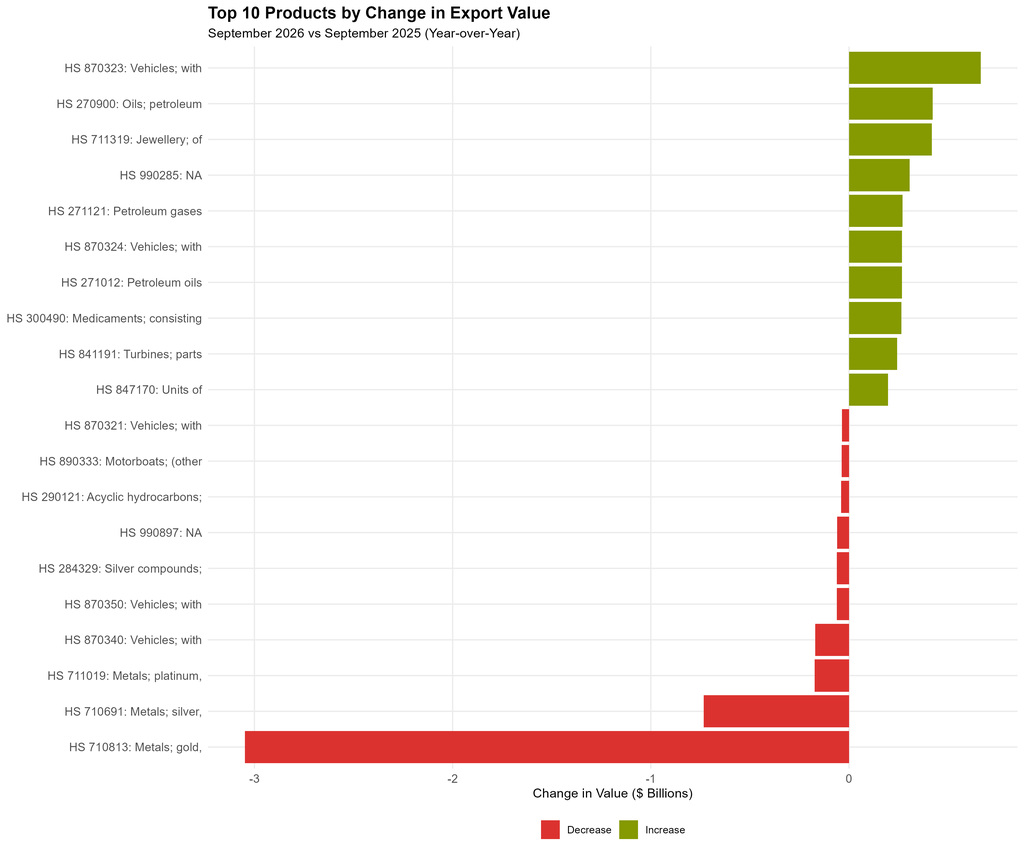

## 2.3 Top Countries - Month-over-Month

### Countries with Largest Increases

Top 5 Export Destinations - Largest Increases (MoM)

| Country | ISO | Sep 2026 | Aug 2026 | Absolute Change | % Change |
| --- | --- | --- | --- | --- | --- |
| Germany | DEU | $4,619.2M | $3,182.9M | $1,436.3M | 45.1% |
| United States | USA | $6,678.7M | $5,991.3M | $687.3M | 11.5% |
| Netherlands | NLD | $3,595.5M | $2,945.2M | $650.3M | 22.1% |
| Italy | ITA | $1,040.1M | $610.3M | $429.8M | 70.4% |
| France | FRA | $2,724.6M | $2,310.1M | $414.5M | 17.9% |

### Countries with Largest Decreases

Top 5 Export Destinations - Largest Decreases (MoM)

| Country | ISO | Sep 2026 | Aug 2026 | Absolute Change | % Change |
| --- | --- | --- | --- | --- | --- |
| Belgium | BEL | $1,782.0M | $2,057.6M | -$275.6M | -13.4% |
| Lithuania | LTU | $53.4M | $155.3M | -$102.0M | -65.6% |
| North Macedonia | MKD | $93.8M | $192.4M | -$98.6M | -51.2% |
| Poland | POL | $802.5M | $900.3M | -$97.8M | -10.9% |
| Singapore | SGP | $765.6M | $834.7M | -$69.1M | -8.3% |

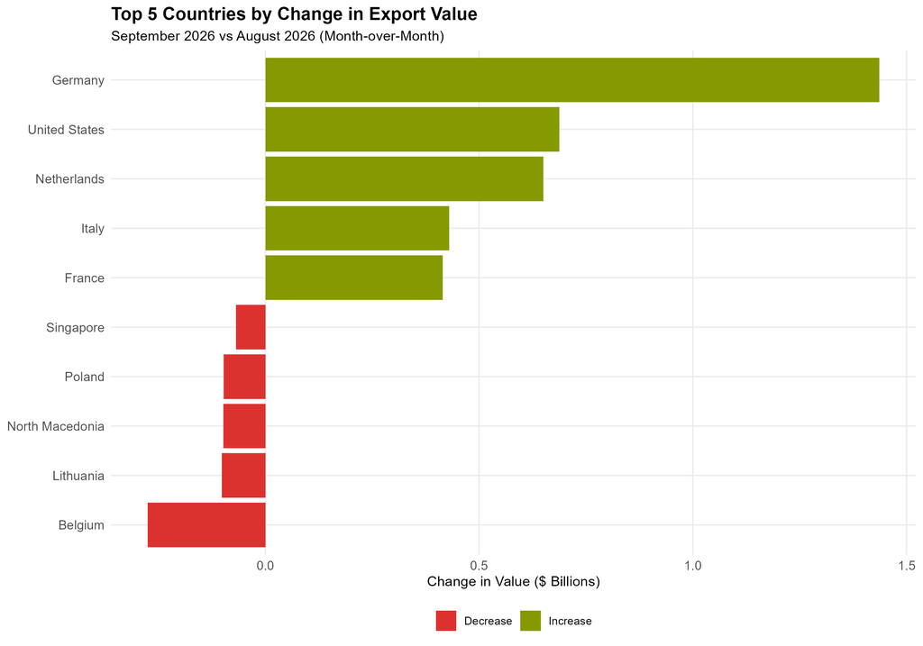

## 2.4 Top Countries - Year-over-Year

### Countries with Largest Increases

Top 5 Export Destinations - Largest Increases (YoY)

| Country | ISO | Sep 2026 | Sep 2025 | Absolute Change | % Change |
| --- | --- | --- | --- | --- | --- |
| China | CHN | $4,756.6M | $2,682.6M | $2,073.9M | 77.3% |
| United States | USA | $6,678.7M | $5,064.9M | $1,613.8M | 31.9% |
| Netherlands | NLD | $3,595.5M | $2,411.9M | $1,183.6M | 49.1% |
| Germany | DEU | $4,619.2M | $3,755.6M | $863.6M | 23.0% |
| Ireland | IRL | $2,975.5M | $2,554.9M | $420.6M | 16.5% |

### Countries with Largest Decreases

Top 5 Export Destinations - Largest Decreases (YoY)

| Country | ISO | Sep 2026 | Sep 2025 | Absolute Change | % Change |
| --- | --- | --- | --- | --- | --- |
| Qatar | QAT | $654.7M | $2,295.1M | -$1,640.5M | -71.5% |
| Hong Kong | HKG | $1,703.0M | $2,564.0M | -$861.0M | -33.6% |
| Oman | OMN | $88.6M | $891.4M | -$802.8M | -90.1% |
| India | IND | $803.1M | $1,263.1M | -$460.0M | -36.4% |
| Poland | POL | $802.5M | $1,163.3M | -$360.8M | -31.0% |

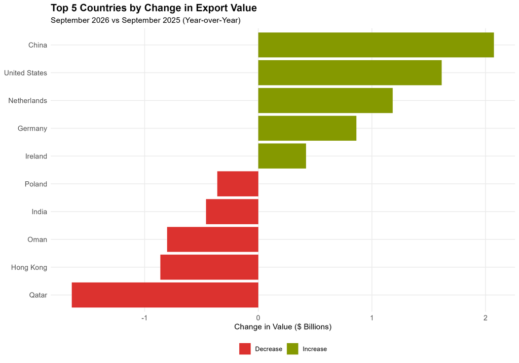

# 3. Import Analysis

## 3.1 Top Products - Month-over-Month

### Products with Largest Increases

Top 10 Import Products - Largest Increases (MoM)

| Product | Sep 2026 | Aug 2026 | Absolute Change | % Change |
| --- | --- | --- | --- | --- |
| HS 710813: Metals; gold, | $27,673.4M | $23,708.7M | $3,964.7M | 16.7% |
| HS 710691: Metals; silver, | $2,148.3M | $802.9M | $1,345.4M | 167.6% |
| HS 270900: Oils; petroleum | $3,016.1M | $2,182.9M | $833.2M | 38.2% |
| HS 847150: Units of | $1,696.0M | $934.6M | $761.4M | 81.5% |
| HS 851713: Telephone sets; | $1,468.7M | $827.2M | $641.6M | 77.6% |
| HS 271019: Petroleum oils | $3,044.5M | $2,563.8M | $480.6M | 18.7% |
| HS 870380: Vehicles; with | $2,016.0M | $1,579.6M | $436.4M | 27.6% |
| HS 841112: Turbo-jets; of | $1,753.6M | $1,379.0M | $374.6M | 27.2% |
| HS 995000: NA | $2,966.9M | $2,664.8M | $302.2M | 11.3% |
| HS 293379: Heterocyclic compounds; | $293.5M | $3.2M | $290.3M | 9146.4% |

### Products with Largest Decreases

Top 10 Import Products - Largest Decreases (MoM)

| Product | Sep 2026 | Aug 2026 | Absolute Change | % Change |
| --- | --- | --- | --- | --- |
| HS 271121: Petroleum gases | $1,118.4M | $1,664.3M | -$545.9M | -32.8% |
| HS 870360: Vehicles; with | $765.2M | $1,181.3M | -$416.1M | -35.2% |
| HS 271600: Electrical energy | $422.6M | $644.5M | -$221.9M | -34.4% |
| HS 990887: NA | $53.5M | $202.3M | -$148.8M | -73.6% |
| HS 780199: Lead; unwrought, | $1.5M | $104.4M | -$102.9M | -98.6% |
| HS 853810: Electrical apparatus; | $15.5M | $86.0M | -$70.5M | -82.0% |
| HS 880240: Aeroplanes and | $491.5M | $557.3M | -$65.9M | -11.8% |
| HS 711299: Waste and | $124.3M | $189.3M | -$65.0M | -34.3% |
| HS 730511: Iron or | $32.7M | $89.0M | -$56.3M | -63.3% |
| HS 100590: Cereals; maize | $18.0M | $73.1M | -$55.1M | -75.4% |

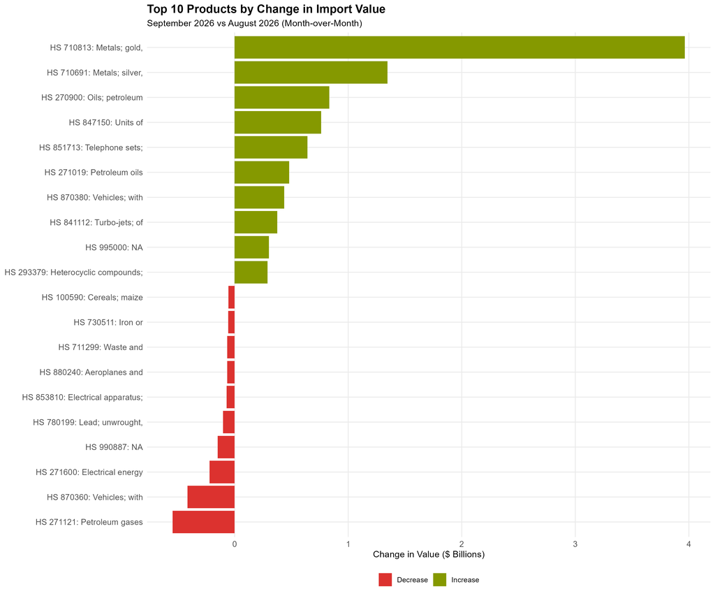

## 3.2 Top Products - Year-over-Year

### Products with Largest Increases

Top 10 Import Products - Largest Increases (YoY)

| Product | Sep 2026 | Sep 2025 | Absolute Change | % Change |
| --- | --- | --- | --- | --- |
| HS 710813: Metals; gold, | $27,673.4M | $9,560.8M | $18,112.6M | 189.4% |
| HS 271019: Petroleum oils | $3,044.5M | $1,769.4M | $1,275.0M | 72.1% |
| HS 710691: Metals; silver, | $2,148.3M | $988.7M | $1,159.6M | 117.3% |
| HS 270900: Oils; petroleum | $3,016.1M | $2,164.4M | $851.7M | 39.3% |
| HS 847150: Units of | $1,696.0M | $845.0M | $851.0M | 100.7% |
| HS 300490: Medicaments; consisting | $1,716.9M | $1,301.2M | $415.7M | 31.9% |
| HS 271012: Petroleum oils | $624.1M | $244.8M | $379.3M | 155.0% |
| HS 851713: Telephone sets; | $1,468.7M | $1,096.2M | $372.5M | 34.0% |
| HS 271121: Petroleum gases | $1,118.4M | $809.1M | $309.3M | 38.2% |
| HS 851762: Communication apparatus | $1,100.8M | $804.9M | $295.9M | 36.8% |

### Products with Largest Decreases

Top 10 Import Products - Largest Decreases (YoY)

| Product | Sep 2026 | Sep 2025 | Absolute Change | % Change |
| --- | --- | --- | --- | --- |
| HS 870322: Vehicles; with | $485.0M | $799.4M | -$314.4M | -39.3% |
| HS 711019: Metals; platinum, | $78.7M | $369.3M | -$290.6M | -78.7% |
| HS 870340: Vehicles; with | $723.8M | $962.4M | -$238.6M | -24.8% |
| HS 870321: Vehicles; with | $282.5M | $448.6M | -$166.1M | -37.0% |
| HS 990285: NA | $212.2M | $374.7M | -$162.4M | -43.4% |
| HS 950450: Games; video | $137.3M | $224.9M | -$87.6M | -38.9% |
| HS 870323: Vehicles; with | $540.7M | $619.9M | -$79.2M | -12.8% |
| HS 880230: Aeroplanes and | $47.0M | $120.8M | -$73.9M | -61.1% |
| HS 870332: Vehicles; with | $196.3M | $261.5M | -$65.2M | -24.9% |
| HS 180400: Cocoa; butter, | $34.3M | $99.4M | -$65.1M | -65.5% |

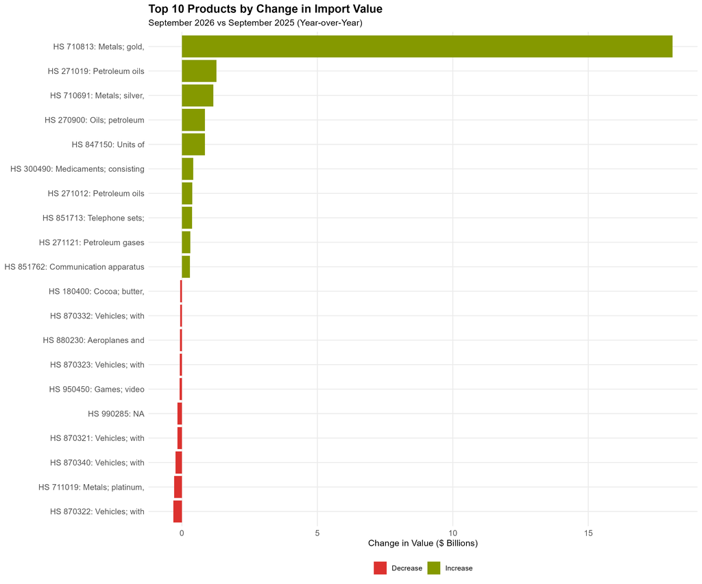

## 3.3 Top Countries - Month-over-Month

### Countries with Largest Increases

Top 5 Import Sources - Largest Increases (MoM)

| Country | ISO | Sep 2026 | Aug 2026 | Absolute Change | % Change |
| --- | --- | --- | --- | --- | --- |
| Switzerland | CHE | $17,621.5M | $13,898.9M | $3,722.6M | 26.8% |
| United States | USA | $10,980.9M | $9,131.4M | $1,849.5M | 20.3% |
| China | CHN | $11,913.1M | $10,343.3M | $1,569.8M | 15.2% |
| Uzbekistan | UZB | $1,382.2M | $1.5M | $1,380.7M | 91315.6% |
| Italy | ITA | $3,902.2M | $2,624.9M | $1,277.3M | 48.7% |

### Countries with Largest Decreases

Top 5 Import Sources - Largest Decreases (MoM)

| Country | ISO | Sep 2026 | Aug 2026 | Absolute Change | % Change |
| --- | --- | --- | --- | --- | --- |
| Singapore | SGP | $205.8M | $2,271.7M | -$2,065.9M | -90.9% |
| Libya | LBY | $93.2M | $184.8M | -$91.6M | -49.6% |
| Guyana | GUY | $2.0M | $85.6M | -$83.6M | -97.7% |
| Saudi Arabia | SAU | $28.9M | $110.5M | -$81.6M | -73.8% |
| Zimbabwe | ZWE | $2.4M | $47.3M | -$44.9M | -94.9% |

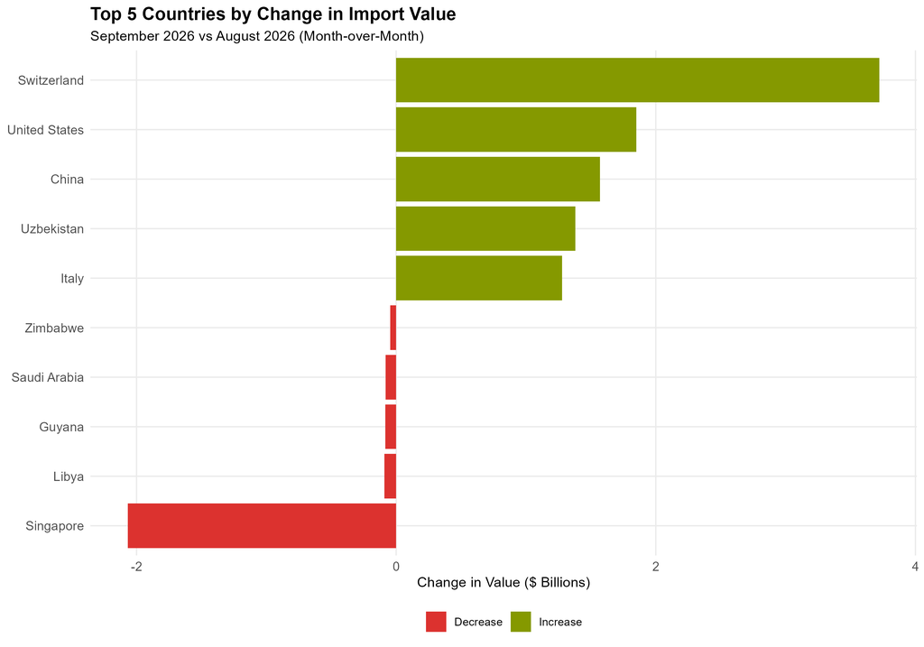

## 3.4 Top Countries - Year-over-Year

### Countries with Largest Increases

Top 5 Import Sources - Largest Increases (YoY)

| Country | ISO | Sep 2026 | Sep 2025 | Absolute Change | % Change |
| --- | --- | --- | --- | --- | --- |
| Switzerland | CHE | $17,621.5M | $3,102.0M | $14,519.5M | 468.1% |
| United States | USA | $10,980.9M | $8,105.1M | $2,875.8M | 35.5% |
| China | CHN | $11,913.1M | $9,929.9M | $1,983.3M | 20.0% |
| Canada | CAN | $4,401.7M | $2,927.0M | $1,474.7M | 50.4% |
| Norway | NOR | $3,053.0M | $1,996.7M | $1,056.3M | 52.9% |

### Countries with Largest Decreases

Top 5 Import Sources - Largest Decreases (YoY)

| Country | ISO | Sep 2026 | Sep 2025 | Absolute Change | % Change |
| --- | --- | --- | --- | --- | --- |
| Guyana | GUY | $2.0M | $241.5M | -$239.5M | -99.2% |
| Saudi Arabia | SAU | $28.9M | $188.2M | -$159.3M | -84.6% |
| Libya | LBY | $93.2M | $229.9M | -$136.7M | -59.5% |
| Brazil | BRA | $471.6M | $572.3M | -$100.7M | -17.6% |
| Mexico | MEX | $514.1M | $602.4M | -$88.4M | -14.7% |

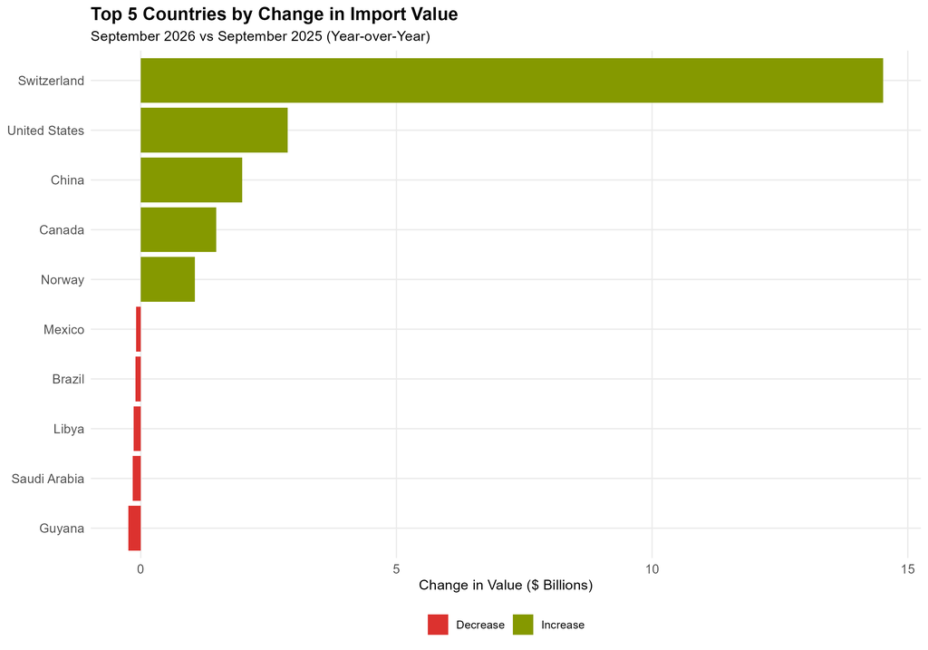

# 4. Methodology

## Data Source

- **Source**: Trade Data Monitor (TDM) API
- **Reporter**: United Kingdom
- **Period**: September 2025 - September 2026
- **Product Classification**: Harmonized System (HS) 6-digit codes
- **Trade Flows**: Both exports (E) and imports (I)

## Calculations

### Growth Rates

- **Month-over-Month (MoM)**: Comparison of September 2026 to August 2026
- **Year-over-Year (YoY)**: Comparison of September 2026 to September 2025

### Rankings

- **Products**: Ranked by absolute change in value (USD)
- **Countries**: Ranked by absolute change in total trade value (USD)
- Top 10 products and top 5 countries shown for both increases and decreases

## Notes

- All values are in US Dollars (USD)
- Trade balance = Exports - Imports (negative values indicate trade deficit)
- Percentage changes may be undefined for products/countries with zero trade in comparison period

# Appendix: Data Files

All detailed data tables are available in the `tables/Sep2026/` directory:

- `overall_trade_metrics_Sep2026.csv`
- `top_products_exports_MoM_Sep2026.csv`
- `top_products_exports_YoY_Sep2026.csv`
- `top_products_imports_MoM_Sep2026.csv`
- `top_products_imports_YoY_Sep2026.csv`
- `top_countries_exports_MoM_Sep2026.csv`
- `top_countries_exports_YoY_Sep2026.csv`
- `top_countries_imports_MoM_Sep2026.csv`
- `top_countries_imports_YoY_Sep2026.csv`

All visualizations are available in the `figures/Sep2026/` directory.